# Invirtiendo el Laplaciano

En R

Elio Campitelli

2017-06-05

Primero hay que poder hacer la transformada en 2D. Esta función toma un campo (en forma de vector) y hacer la transformada de Fourier o su inversa. Devuelve una lista con las componentes de Fourier para cada combinación de números de onda en x e y.

```r
fft2d <- function(v, x, y, inverse = FALSE) {
    field <- as.matrix(reshape2::dcast(data.table(v, x, y),
                             x ~ y, value.var = "v"))

    field.fft <- fft(field[, -1], inverse = inverse)
    dimnames(field.fft) <- list(
        k = 1:nrow(field.fft) - 1,
        l = 1:ncol(field.fft) - 1)

    field.fft <- setDT(melt(field.fft, value.name = "f"))
    return(with(field.fft, list(k, l, f)))
}
```

La probamos con una función simple:

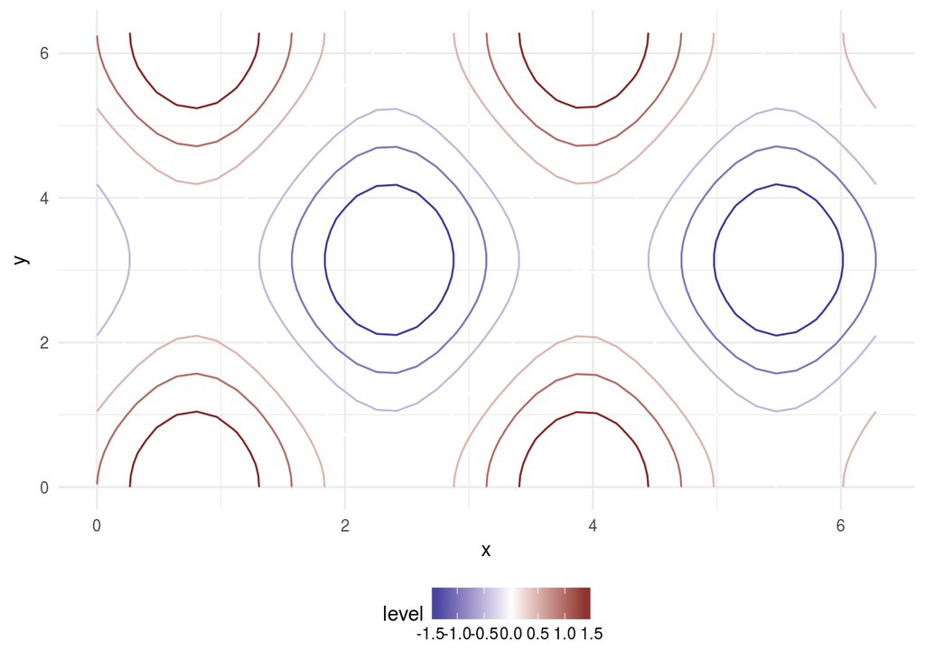

```r
test.fun <- function(x, y) {
    sin(x*2) + cos(y)
}

test.fun.lap <- function(x, y) {
    -4*sin(x*2) - cos(y)
}


test <- setDT(expand.grid(
    x = seq(0, 2*pi, length.out = 40),
    y = seq(0, 2*pi, length.out = 40)
))
test[, z := test.fun(x, y)]

ggplot(test, aes(x, y)) +
    geom_contour(aes(z = z, color = ..level..)) +
    scale_color_divergent()
```

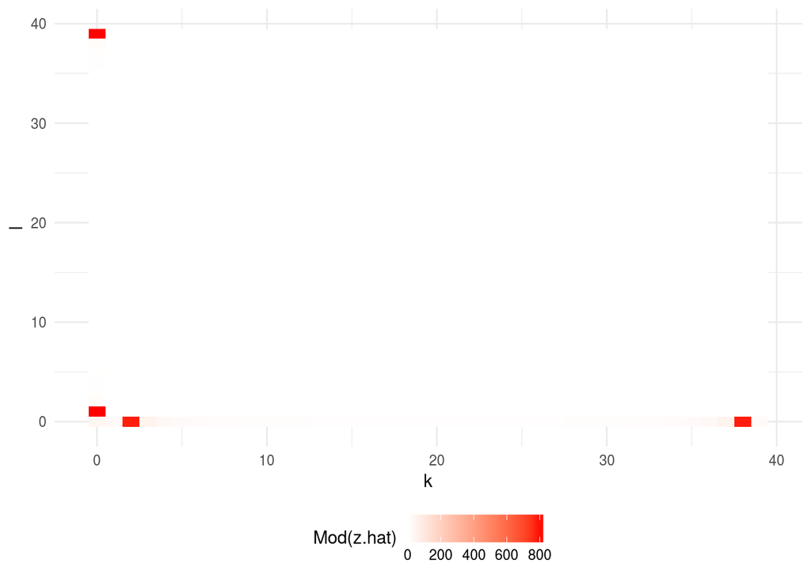

```r
test.fft <- test[, setNames(fft2d(z, x, y),
                            c("k", "l", "z.hat"))]

ggplot(test.fft, aes(k, l)) +
    geom_tile(aes(fill = Mod(z.hat))) +
    scale_fill_gradient(low = "white", high = "red")
```

Vamos a ver que podemos obtener la función original (a menos de algunas constantes que dan vuelta por ahí) invirtiendo la transformada:

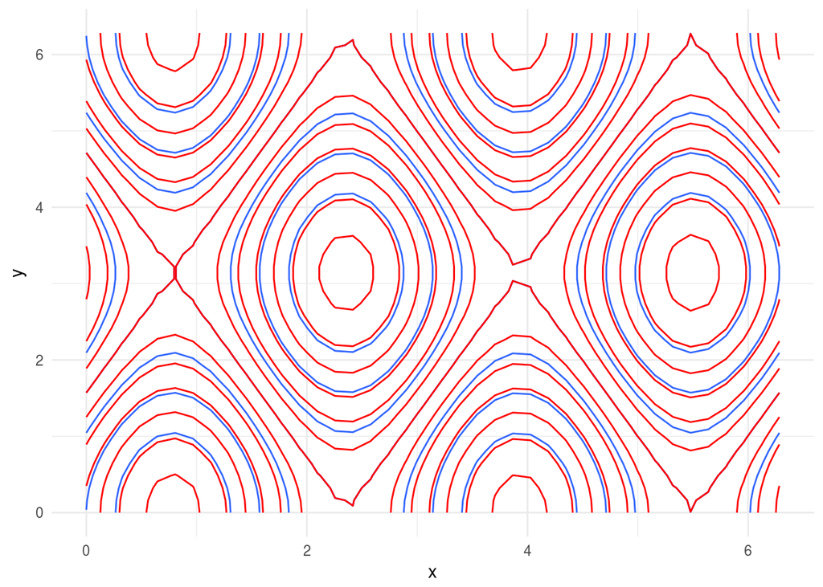

```r
test[, z.inverse := Re(test.fft[, setNames(fft2d(z.hat, k, l, inverse = TRUE),
                            c("x", "y", "z"))]$z)]

ggplot(test, aes(x, y)) +
    geom_contour(aes(z = z)) +
    geom_contour(aes(z = z.inverse), color = "red")
```

Esta función anda bien, así que se puede usar para invertir el laplaciano:

Esta función toma un campo (de nuevo, en forma de vector) y le aplica la inversa del laplaciano a partir de la transformada de fourier.

```r
InverseLaplacian <- function(v, x, y) {
    a <- 6371000
    field <- data.table(x, y, v)

    field[, c("k", "l", "v.hat") := fft2d(v, x, y)]
    # field[, lp := l*2*pi/a]
    # field[, kp := k*2*pi/(a*cos(y*pi/180))]

    field[, v.hat := -v.hat/(k^2 + l^2)]
    # field[, v.hat := -v.hat/(kp^2 + lp^2)]

    # El modo de k = l = 0 me queda infinito. Como no es demasiado importante (es una constante),
    # lo igualo a 0.
    field[, v.hat := c(0, v.hat[2:.N])]

    field[, c("k", "l", "v.inv") := fft2d(v.hat, k, l, inverse = TRUE)]
    return(Re(field$v.inv))
}
```

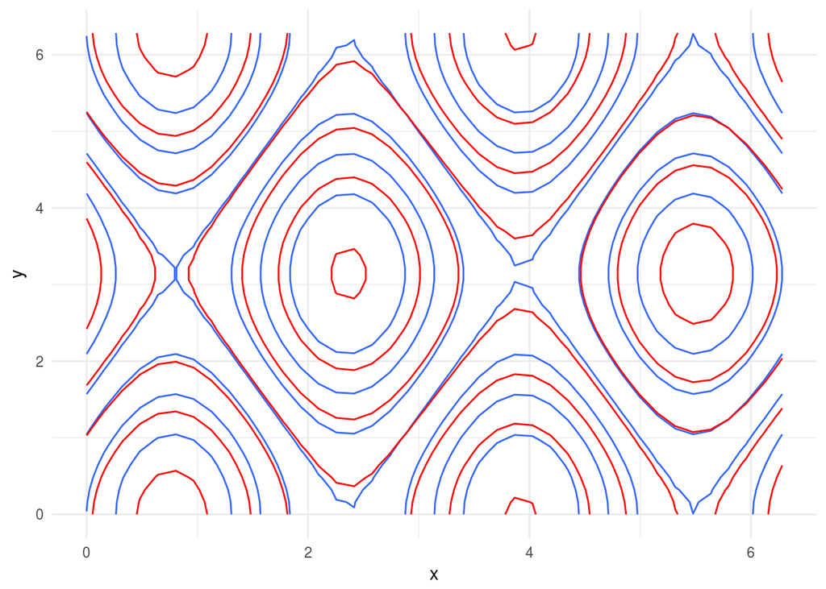

```r
test[, z.lap := test.fun.lap(x, y)]
test[, z.inv := InverseLaplacian(z.lap, x, y)]

ggplot(test, aes(x, y)) +
    geom_contour(aes(z = z)) +
    geom_contour(aes(z = z.inv), color = "red")
```

¡Éxito!. A menos de una constante aditiva y una multiplicativa, obtengo el campo original.

Vamos a aplicarlo a un campo más realista. La altura geopotencial según NCEP.

```r
ncep <- ReadNetCDF("DATA/NCEP/hgt.mon.mean.nc", vars = "hgt")
setnames(ncep, c("level", "hgt"), c("lev", "gh"))
ncep <- ncep[lev == 300 & date == date[1]]

ncep[, gh := gh - mean(gh), by = lat]
```

Para calcular el laplaciano, voy a tener que derivar:

```r
Derivate <- function(x, y, order = 1, bc = "cyclic") {
    # Calcula derivada centrada 1da o 2da
    # Entra:
    #  x: la variable a derivar
    #  y: la variable que deriva
    #  order: orden de la derivada (1 o 2)
    #  bc: condiciones de borde (por ahora, sólo impliementadas cíclicas o nada)
    # Sale:
    #  un vector de la misma longitud que x e y con la derivada
    # ¡Asume que la grilla es uniforme!
    library(data.table)
    N <- length(x)

    d <- y[2] - y[1]

    if (order == 1) {
        dxdy <- (x[c(2:N, 1)] - x[c(N, 1:(N-1))])/(2*d)

    } else if (order == 2) {
        dxdy <- (x[c(2:N, 1)] + x[c(N, 1:(N-1))] - 2*x)/d^2
    }
    if (bc != "cyclic") {
        dxdy[c(1, N)] <- NA
    }

    return(dxdy)
}
```

Listo, ahora a partir del laplaciano del geopotencial:

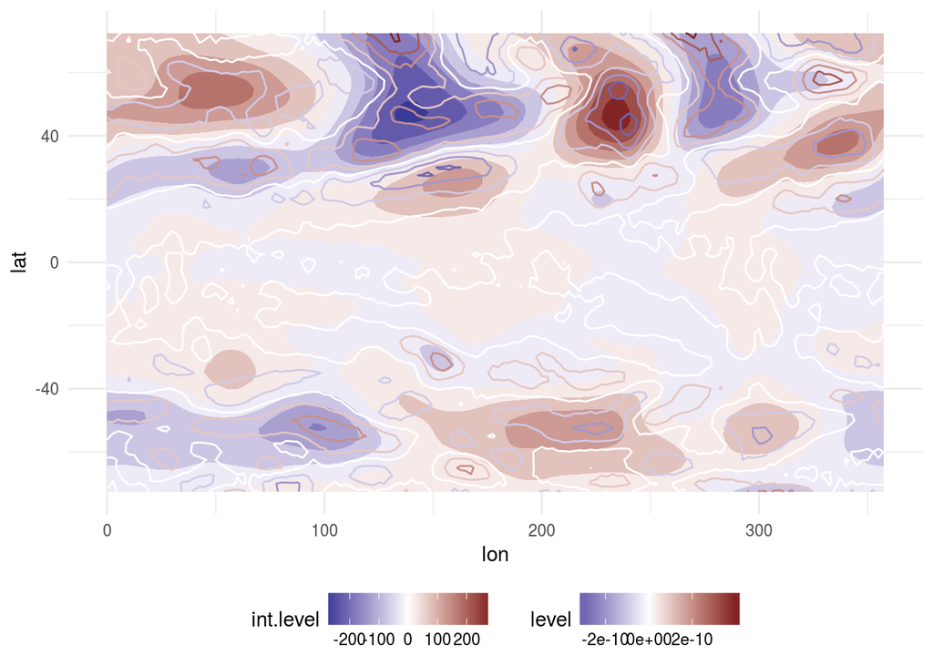

Geopotencial en sombreado, laplaciano del geopotencial en contornos.

```r
a <- 6731000
ncep[, gh.dxx := Derivate(gh, lon*pi/180, 2)/(a*cos(lat*pi/180))^2, by = lat]
ncep[, gh.dyy := Derivate(gh, lat*pi/180, 2, bc = "none")/a^2, by = lon]
ncep[, gh.lap := gh.dxx + gh.dyy]

ggplot(ncep[abs(lat) < 75], aes(lon, lat)) +
    stat_fill_contour(aes(z = gh)) +
    geom_contour(aes(color = ..level.., z = gh.lap)) +
    scale_fill_divergent() +
    scale_color_divergent()
```

Puedo intentar obtener el geopotencial original:

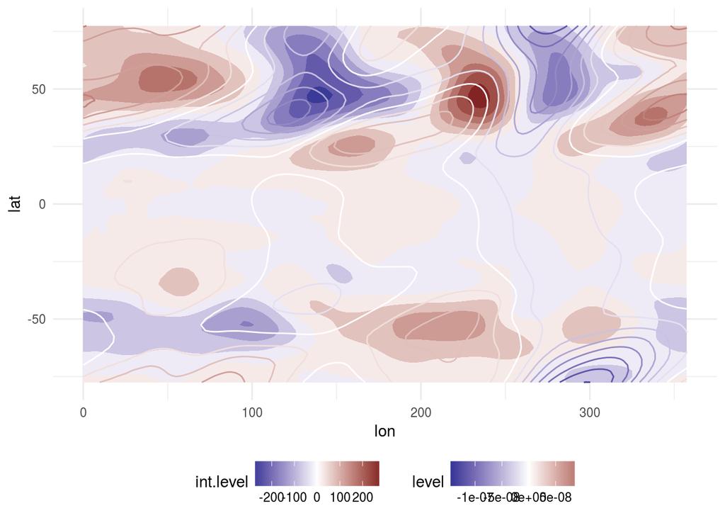

Geopotencial en sombreado, laplaciano invertido en contornos

```r
ncep[!is.na(gh.lap), gh.inv := InverseLaplacian(gh.lap, lon*pi/180, -lat*pi/180)]

ggplot(ncep[abs(lat) < 80], aes(lon, lat)) +
    stat_fill_contour(aes(z = gh)) +
    geom_contour(aes(y = lat, z = gh.inv, color = ..level..)) +
    scale_fill_divergent() +
    scale_color_divergent()
```

Más o menos. Los centros coinciden un poco, pero la verdad es que es un porquería.

Además, hay un problema adicional. Si no uso los datos globales para calcular invertir el laplaciano, el restulado es distinto:

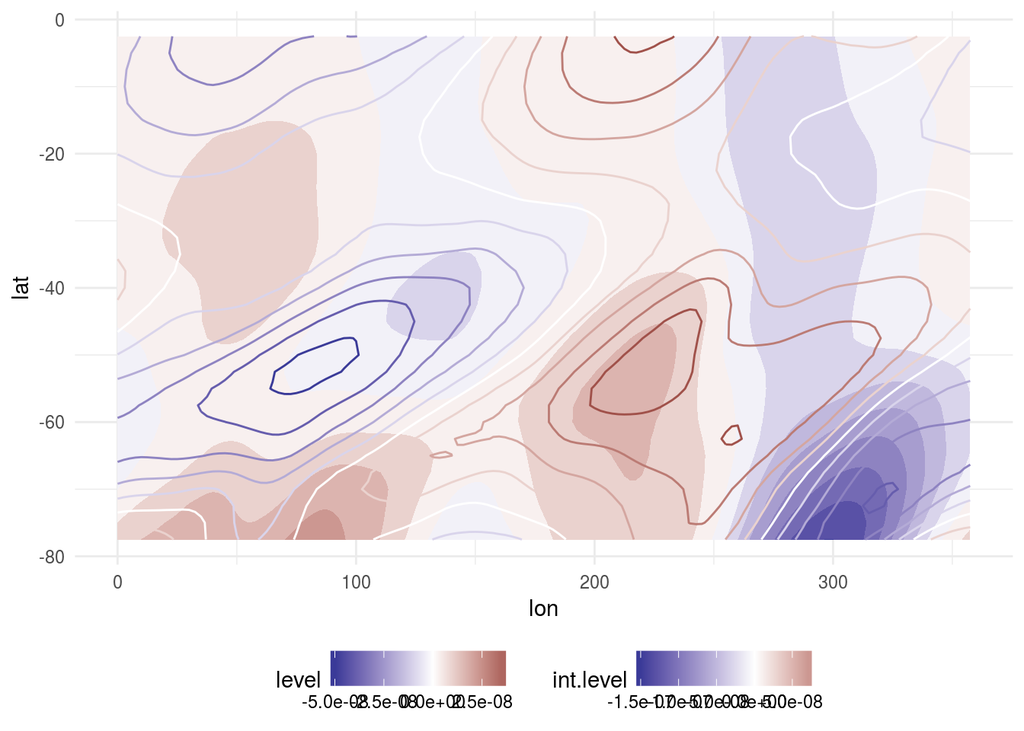

Laplaciano invertido usando todo el globo en sombreado, laplaciano invertido usando sólo el hemisferio suro en contornos.

```r
ncep[!is.na(gh.lap) & lat < 0, gh.inv.SH := InverseLaplacian(gh.lap, lon*pi/180, -lat*pi/180)]

ggplot(ncep[lat < 0 & lat > -80], aes(lon, lat)) +
    stat_fill_contour(aes(z = gh.inv)) +
    geom_contour(aes(y = lat, z = gh.inv.SH, color = ..level..)) +
    scale_fill_divergent() +
    scale_color_divergent()
```